# Analiza Corelațiilor Canonice (ACC)

Această tehnică ne permite să studiem relația complexă dintre **două seturi distincte de variabile** care descriu aceleași mașini. Nu ne uităm doar la o variabilă vs alta (ex: Putere vs Preț), ci la cum influențează un *întreg grup* de caracteristici pe celălalt.

```python
from utils import *
import numpy as np
import pandas as pd
from sklearn.cross_decomposition import CCA
from sklearn.preprocessing import StandardScaler
import matplotlib.pyplot as plt
import seaborn as sb

masini=pd.read_csv('SET DE DATE/Specificatii masini 2023.csv',index_col=(0,1))
replaceNan(masini)
masini.head()
```

| Company | Model | Segment | Fuel | Power(HP) | Torque(Nm) | Displacement | Length | Width | Height | Wheelbase | Cargo Volume | Unladen Weight | Top Speed | Acceleration 0-62 Mph (0-100 kph) | Combined mpg | Fuel capacity |
| --- | --- | --- | --- | --- | --- | --- | --- | --- | --- | --- | --- | --- | --- | --- | --- | --- |
| ALFA ROMEO | ALFA ROMEO Giulia (2022-Present) | Compact | Gasoline | 280.0 | 400.0 | 1995.0 | 183.1 | 73.2 | 56.6 | 111.0 | 17.0 | 3406.0 | 149.0 | 5.2 | 30.5 | 15.3 |
|  | ALFA ROMEO Giulia (2022-Present) | Compact | Diesel | 210.0 | 470.0 | 2143.0 | 183.1 | 73.2 | 56.6 | 111.0 | 17.0 | 3450.0 | 146.0 | 6.8 | 42.8 | 15.3 |
|  | 2023 Alfa Romeo Stelvio | Medium SUV | Gasoline | 280.0 | 400.0 | 1995.0 | 184.5 | 74.9 | 66.7 | 110.9 | 18.5 | 3704.0 | 143.0 | 5.7 | 28.0 | 16.9 |
|  | 2023 Alfa Romeo Stelvio | Medium SUV | Diesel | 210.0 | 470.0 | 2143.0 | 184.5 | 74.9 | 66.7 | 110.9 | 18.5 | 3847.0 | 134.0 | 6.6 | 36.8 | 16.9 |
|  | ALFA ROMEO Giulietta (2016-Present) | Compact | Gasoline | 120.0 | 215.0 | 1368.0 | 171.3 | 70.8 | 57.7 | 103.7 | 12.4 | 2987.0 | 121.0 | 9.4 | 37.9 | 15.9 |

## Structura Analizei

Am divizat datele în cele două seturi de interes pentru a testa ipoteza: *"Performanța dictează gabaritul?"*

1. **Setul X (Performanță & Dinamică):** Variabilele care definesc cât de "rapidă" este mașina (*Power, Torque, Top Speed, Acceleration*).
2. **Setul Y (Dimensiuni & Masă):** Variabilele care definesc "corpul" mașinii (*Length, Width, Wheelbase, Unladen Weight*).

Vom căuta perechi de **variabile canonice** (u, v) care să explice legătura dintre aceste două lumi: motorizare vs. caroserie.

```python
variabile_set1=['Power(HP)','Torque(Nm)','Top Speed','Acceleration 0-62 Mph (0-100 kph)']
variabile_set2=['Length','Width','Wheelbase','Unladen Weight']

x_orig=masini[variabile_set1].values
y_orig=masini[variabile_set2].values

x=StandardScaler().fit_transform(x_orig)
y=StandardScaler().fit_transform(y_orig)

n,p=x.shape
_,q=y.shape
nr_comp=min(p,q)
```

## Crearea modelului

```python
model_acc=CCA(n_components=nr_comp)
model_acc.fit(x,y)

eticheteZ=['Z'+str(i+1) for i in range(nr_comp)]
eticheteU=['U'+str(i+1) for i in range(nr_comp)]
etichete_radacini=['Radacina'+str(i+1) for i in range(nr_comp)]
```

## Scoruri

```python
z,u=model_acc.transform(x,y)
zDf=toDataFrame(z,masini.index,eticheteZ,'Zscore.csv')
uDf=toDataFrame(u,masini.index,eticheteU,'Uscores.csv')
zDf.head()
```

| Company | Model | Z1 | Z2 | Z3 | Z4 |
| --- | --- | --- | --- | --- | --- |
| ALFA ROMEO | ALFA ROMEO Giulia (2022-Present) | 0.553369 | -0.028695 | -0.014019 | -1.062766 |
|  | ALFA ROMEO Giulia (2022-Present) | 0.762826 | 0.089228 | -0.591546 | -0.164271 |
|  | 2023 Alfa Romeo Stelvio | 0.588573 | -0.245539 | 0.063250 | -0.965838 |
|  | 2023 Alfa Romeo Stelvio | 0.946190 | -0.572742 | -0.532990 | -0.524708 |
|  | ALFA ROMEO Giulietta (2016-Present) | -0.612475 | -0.294127 | -0.108774 | -0.528328 |

```python
uDf.head()
```

| Company | Model | U1 | U2 | U3 | U4 |
| --- | --- | --- | --- | --- | --- |
| ALFA ROMEO | ALFA ROMEO Giulia (2022-Present) | -0.070632 | 0.033291 | -0.515172 | 0.372524 |
|  | ALFA ROMEO Giulia (2022-Present) | -0.010757 | 0.006955 | -0.487686 | 0.336326 |
|  | 2023 Alfa Romeo Stelvio | 0.362493 | 0.041666 | -0.074437 | 0.284080 |
|  | 2023 Alfa Romeo Stelvio | 0.557087 | -0.043928 | 0.014893 | 0.166435 |
|  | ALFA ROMEO Giulietta (2016-Present) | -0.589838 | -0.064293 | 0.026420 | -0.049690 |

Aceste valori sunt coordonatele mașinilor în noul spațiu al corelației.

- **Scorurile Z :** Reprezintă "profilul sintetic" al mașinii bazat strict pe *Performanță* (Setul 1).
- **Scorurile U :** Reprezintă "profilul sintetic" bazat strict pe *Dimensiuni* (Setul 2). *Exemplu Interpretare:* La *Alfa Romeo Stelvio*, vedem un scor Z1 pozitiv (0.58) și un scor U1 pozitiv (0.36), ceea ce confirmă că există o coerență: performanțele ridicate (Z) sunt aliniate cu dimensiunile mari (U).

## Funcția Bartlett

```python
def test_bartlett(r2,n,p,q,m):
    v=1-r2
    chi2=(-n+1+(p+q+1)/2)*np.log(np.flip(np.cumprod(np.flip(v))))
    n_lib=[ (p-k+1)*(q-k+1)
        for k in range(1,(m+1))
    ]
    p_values=1-stts.chi2.cdf(chi2,n_lib)
    return p_values
```

Înainte de a interpreta rezultatele, trebuie să demonstrăm matematic că cele două seturi (Performanță vs. Dimensiuni) sunt într-adevăr legate, și nu doar corelate din întâmplare. Testul Bartlett verifică ipoteza nulă ("Nu există nicio legătură"). Dacă valorile *p (p-values)* sunt sub 0.05, respingem nulul și confirmăm că există o structură canonică semnificativă statistic între cele două grupuri de variabile. Practic, ne dă "undă verde" pentru interpretare.

## Corelatiile dintre z si u

```python
r_z_u=np.array([
    np.corrcoef(z[:,i],u[:,i])[0,1]
    for i in range(nr_comp)]
)
r_z_u_patrat=r_z_u**2
p_values=test_bartlett(r_z_u_patrat,n,p,q,nr_comp)
df1=pd.DataFrame({
    'R_z_u':r_z_u,
    'R_z_u patrat':r_z_u_patrat,
    'P_value':p_values
},
index=etichete_radacini)
df1.head(4)
```

|  | R_z_u | R_z_u patrat | P_value |
| --- | --- | --- | --- |
| Radacina1 | 0.760692 | 0.578652 | 0.000000e+00 |
| Radacina2 | 0.310805 | 0.096600 | 0.000000e+00 |
| Radacina3 | 0.160378 | 0.025721 | 4.725129e-09 |
| Radacina4 | 0.019880 | 0.000395 | 4.140875e-01 |

Tabelul arată intensitatea legăturii pentru fiecare pereche de variabile canonice extrase:

1. **Rădăcina 1 (0.76):** Corelație puternică și foarte semnificativă statistic (p < 0.05, foarte apropiat de 0). Aceasta captează legătura principală dintre performanță și dimensiuni (axa "Mărime = Putere").
2. **Rădăcina 2 (0.31):** Corelație moderată, dar semnificativă. Indică o a doua relație, mai subtilă, independentă de prima.
3. **Rădăcina 3 (0.16):** Corelație slabă, totuși semnificativă statistic.
4. **Rădăcina 4 (0.02):** P-value > 0.05 (0.41), deci această legătură este **nesemnificativă statistic**. O vom ignora în interpretare, deoarece poate fi doar zgomot aleatoriu.

## Corealatiile dintre x&z si y&u

```python
r_x_z=np.corrcoef(x,z,rowvar=False)[:nr_comp,nr_comp:]
r_x_zDf=toDataFrame(r_x_z,variabile_set1,eticheteZ,'R_x_z.csv')
r_y_u=np.corrcoef(y,u,rowvar=False)[:nr_comp,nr_comp:]
r_y_uDf=toDataFrame(r_y_u,variabile_set2,eticheteU,'R_y_u.csv')
r_x_zDf.head()
```

|  | Z1 | Z2 | Z3 | Z4 |
| --- | --- | --- | --- | --- |
| Power(HP) | 0.815004 | 0.198557 | 0.530846 | -0.120611 |
| Torque(Nm) | 0.990250 | 0.087858 | -0.055873 | 0.092543 |
| Top Speed | 0.704197 | 0.648363 | 0.058058 | -0.283482 |
| Acceleration 0-62 Mph (0-100 kph) | -0.775261 | -0.278015 | -0.020571 | 0.566793 |

```python
r_y_uDf.head()
```

|  | U1 | U2 | U3 | U4 |
| --- | --- | --- | --- | --- |
| Length | 0.758186 | 0.491773 | -0.425487 | 0.047685 |
| Width | 0.702958 | 0.420854 | 0.308082 | 0.483546 |
| Wheelbase | 0.761537 | 0.146189 | -0.548988 | 0.311933 |
| Unladen Weight | 0.994818 | 0.028620 | -0.086292 | -0.045516 |

Aici vedem "miezul" relației dintre cele două seturi (cea mai puternică legătură, R=0.76).

**Setul 1 (Performanță - Z1):**

- *Power (0.81), Torque (0.99), Top Speed (0.70):* Corelații pozitive foarte puternice.
- *Acceleration (-0.77):* Corelație negativă puternică (logic, secunde mai puține înseamnă mașină mai rapidă).
- **Concluzie Z1:** Această axă definește **"Mașinile de Înaltă Performanță"**.

**Setul 2 (Dimensiuni - U1):**

- *Unladen Weight (0.99), Length (0.75), Wheelbase (0.76):* Toate au corelații pozitive masive.
- **Concluzie U1:** Această axă definește **"Mașinile Masive și Grele"**.

## Variante si redundante

```python
v_x_z=np.mean(r_x_z**2,axis=0)
v_y_u=np.mean(r_y_u**2,axis=0)
redundanta_x=v_x_z*r_z_u_patrat
reduntanta_y=v_y_u*r_z_u_patrat

df2=pd.DataFrame(
    {
        'V_x_z':v_x_z,
        'Redundanta x':redundanta_x,
        'V_y_u':v_y_u,
        'Redundanta y':reduntanta_y
    },index=etichete_radacini
)
df2.head()
```

|  | V_x_z | Redundanta x | V_y_u | Redundanta y |
| --- | --- | --- | --- | --- |
| Radacina1 | 0.685437 | 0.396629 | 0.659650 | 0.381707 |
| Radacina2 | 0.136203 | 0.013157 | 0.110287 | 0.010654 |
| Radacina3 | 0.072178 | 0.001857 | 0.146197 | 0.003760 |
| Radacina4 | 0.106182 | 0.000042 | 0.083866 | 0.000033 |

Acest tabel ne spune **cât de mult contează** legăturile descoperite în realitate:

- **Varianța Extrasă (V_x_z = 68%, V_y_u = 65%):** Prima pereche canonică este extrem de eficientă. Doar prima axă (Z1/U1) reușește să sintetizeze aproximativ **două treimi** din toată informația conținută în seturile originale de date.
- **Redundanța (~38-39%):** Aceasta este cifra cheie. Ne spune că aproximativ **40% din variația performanțelor unei mașini poate fi prezisă strict știind dimensiunile ei** (și invers). Restul de 60% depinde de tehnologie specifică, aerodinamică sau eficiența motorului, nu doar de mărime.

## Grafice

### Heatmap pentru corelatiile dintre variabilele initiale si componente create

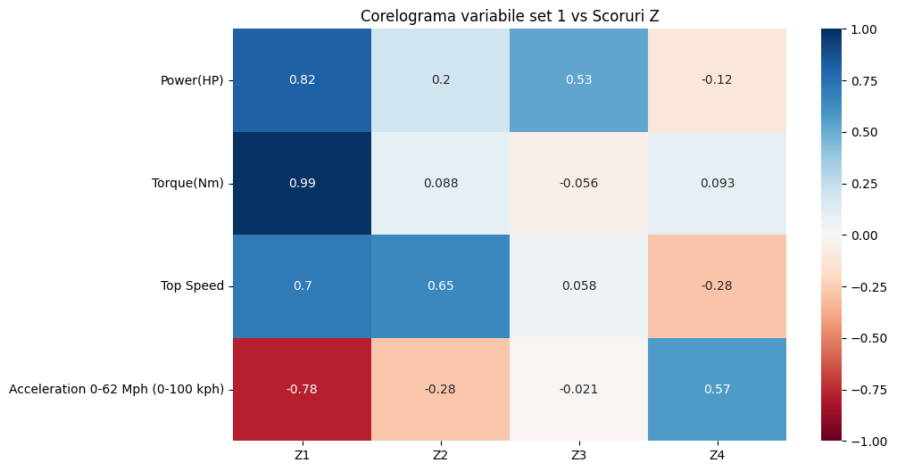

```python
plt.figure(figsize=(10,6))
plt.title('Corelograma variabile set 1 vs Scoruri Z')
sb.heatmap(r_x_zDf, annot=True, cmap='RdBu', vmin=-1, vmax=1);
```

Heatmap-ul arată ce variabile originale construiesc fiecare axă canonică nouă:

1. **Axa Z1 ("Forța Brută"):**
   - Este dominată de *Torque (0.99)* și *Power (0.82)*.
   - Este axa motoarelor mari, cu mult cuplu, capabile să tragă o mașină grea. Observăm că *Accelerarea* este negativă (-0.78), deci Z1 înseamnă mașini care demarează rapid.
2. **Axa Z2 ("Viteza Pură"):**
   - Este corelată semnificativ doar cu *Top Speed (0.65)*.
   - Această axă nuanțează prima: există mașini puternice (Z1 mare) care nu sunt neapărat făcute pentru viteză maximă extremă (spre deosebire de supercar-uri, care ar avea și Z2 mare).

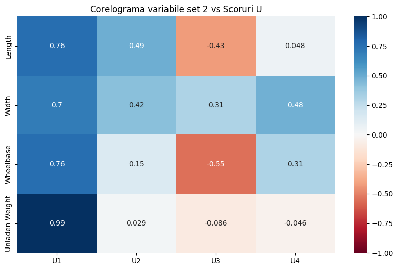

```python
plt.figure(figsize=(10,6))
plt.title('Corelograma variabile set 2 vs Scoruri U')
sb.heatmap(r_y_uDf, annot=True, cmap='RdBu', vmin=-1, vmax=1);
```

Aici vedem imaginea în oglindă, din perspectiva caroseriei:

1. **Axa U1 ("Gabariul Total"):**
   - Este definită covârșitor de **Unladen Weight (0.99)**, dar și de **Lungime (0.76)** și **Ampatament (0.76)**.
   - U1 este pur și simplu axa "Cât de mare și grea e mașina".
2. **Axa U2 ("Proporția"):**
   - Vedem corelații medii cu **Lungimea (0.49)** și **Lățimea (0.42)**, dar aproape zero cu Greutatea.
   - Această axă separă mașinile lungi și late (limuzinele aerodinamice) de cele grele dar compacte (SUV-uri scurte), nuanțând forma caroseriei.

### Scatter plot pentru a arata distributia observatiilor in legatura (z1,u1) - cea mai importanta componenta

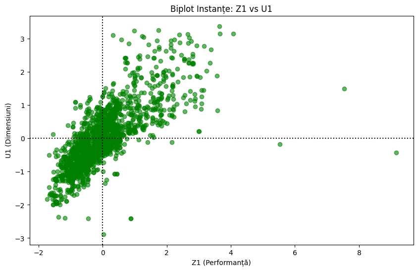

```python
plt.figure(figsize=(10,6))
plt.title('Biplot Instanțe: Z1 vs U1')
plt.scatter(z[:, 0], u[:, 0], alpha=0.6, color='green')
plt.xlabel('Z1 (Performanță)')
plt.ylabel('U1 (Dimensiuni)')
plt.axhline(0, color='black', linestyle=':')
plt.axvline(0, color='black', linestyle=':');
```

Graficul confirmă vizual, fără dubiu, ceea ce am văzut în cifre:

- **Tendința Diagonală:** Punctele verzi (mașinile) se aliniază clar pe o diagonală ascendentă. Asta înseamnă că, aproape invariabil, o creștere a scorului Z (Performanță) vine la pachet cu o creștere a scorului U (Dimensiuni).
- **Outlieri:** Punctele rare care se abat de la diagonală (ex: în dreapta jos, Z mare dar U mic, sau stânga sus) sunt excepțiile interesante: mașini foarte puternice dar compacte (Hot Hatches) sau mașini foarte mari dar leneșe (dube/MPV-uri ieftine), însă tendința generală a pieței este de aliniere masivă.

### Cercul corelatiilor dintre x si z

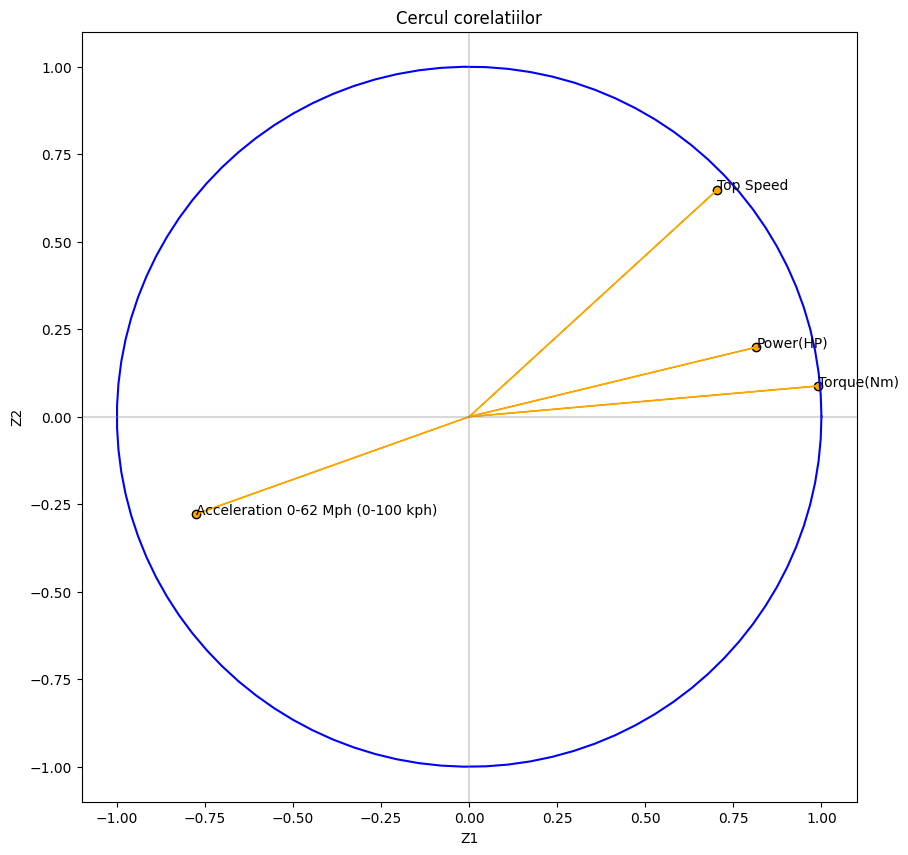

```python
plt.figure(figsize=(10,10))
plt.title('Cercul corelatiilor')
x_coords=r_x_z[:,0]
y_coords=r_x_z[:,1]
plt.scatter(x_coords,y_coords,color='orange',edgecolors='black')

theta=np.linspace(0,2*np.pi,100)
plt.plot(np.cos(theta),np.sin(theta),color='blue',linestyle='-')

for i in range(len(variabile_set1)):
    plt.arrow(0,0,x_coords[i],y_coords[i],color='orange')
    plt.annotate(variabile_set1[i],(x_coords[i],y_coords[i]))

plt.xlabel('Z1')
plt.ylabel('Z2')
plt.axhline(y=0,alpha=0.3,color='gray')
plt.axvline(x=0,color='gray',alpha=0.3)
plt.xlim(-1.1,1.1)
plt.ylim(-1.1,1.1);
```

Graficul vectorilor confirmă geometria relațiilor dintre variabilele tehnice:

### Cercul corelatiilor dintre y si u

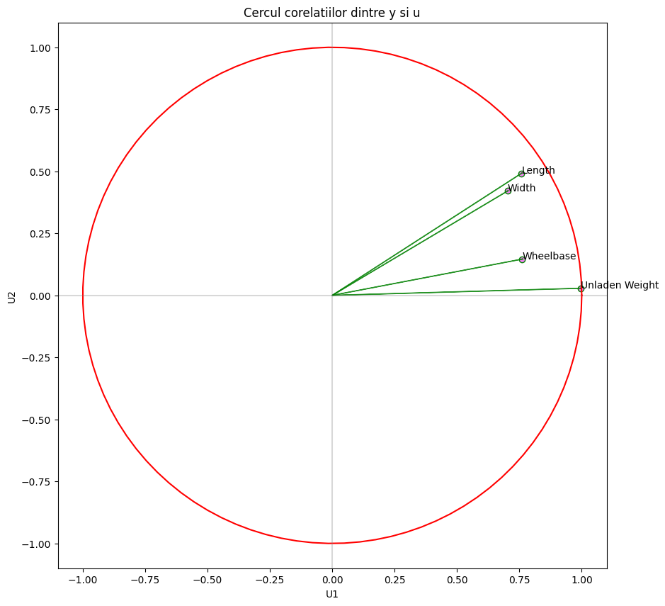

```python
plt.figure(figsize=(10,10))
plt.title('Cercul corelatiilor dintre y si u')
k_coords=r_y_u[:,0]
l_coords=r_y_u[:,1]
plt.scatter(k_coords,l_coords,color='violet',edgecolors='green')

theta=np.linspace(0,2*np.pi,100)
plt.plot(np.cos(theta),np.sin(theta),color='red')

for i in range( len(variabile_set2)):
    plt.arrow(0,0,k_coords[i],l_coords[i],alpha=0.8,color='green')
    plt.annotate(variabile_set2[i],(k_coords[i],l_coords[i]))

plt.xlabel('U1')
plt.ylabel('U2')
plt.axhline(y=0,alpha=0.3,color='gray')
plt.axvline(x=0,color='gray',alpha=0.3)
plt.xlim(-1.1,1.1)
plt.ylim(-1.1,1.1);
```

Acest grafic explică geometria "corpului" mașinii:

- **Axa Orizontală (U1):** Vectorul *Unladen Weight* se suprapune aproape perfect peste axă. Asta confirmă că U1 măsoară, în primul rând, *Masa Totală*. Toate celelalte variabile (*Length, Width, Wheelbase*) sunt și ele proiectate puternic spre dreapta, arătând că, în general, mașinile grele sunt și mari.
- **Axa Verticală (U2):** Aici se diferențiază *Lungimea (Length)* și *Lățimea (Width)*, care au o componentă verticală notabilă.
  - Aceasta sugerează o nuanță de "Formă": există mașini foarte grele care nu sunt neapărat extrem de lungi (SUV-uri compacte blindate/electrice - U1 mare, U2 mic), versus mașini lungi și late care "ocupă mult loc" (limuzine - U1 mare, U2 mare).